# Assignment 0

## September 20 2018

```python
import pandas as pd
import glmnet_python
from glmnet import glmnet
from glmnet_python import *
## readin csv and drop nans
hitter=pd.read_csv("Hitters.csv").dropna()
```

## Problem 1.1

```python
##hitter.head(n=5)
## Drop the unnamed column
hitter=hitter.drop(hitter.columns[hitter.columns.str.contains('unnamed',case = False)],axis = 1)
##hitter.head(n=5)
hitter.info()
```

```
<class 'pandas.core.frame.DataFrame'>
Int64Index: 263 entries, 1 to 321
Data columns (total 20 columns):
AtBat        263 non-null int64
Hits         263 non-null int64
HmRun        263 non-null int64
Runs         263 non-null int64
RBI          263 non-null int64
Walks        263 non-null int64
Years        263 non-null int64
CAtBat       263 non-null int64
CHits        263 non-null int64
CHmRun       263 non-null int64
CRuns        263 non-null int64
CRBI         263 non-null int64
CWalks       263 non-null int64
League       263 non-null object
Division     263 non-null object
PutOuts      263 non-null int64
Assists      263 non-null int64
Errors       263 non-null int64
Salary       263 non-null float64
NewLeague    263 non-null object
dtypes: float64(1), int64(16), object(3)
memory usage: 43.1+ KB
```

```python
y_=hitter.Salary.values
##Drop Categorical data and convert dataframe to matrix
x_=hitter.drop(['Salary', 'League', 'Division', 'NewLeague'], axis = 1).reset_index().values.astype('float64')
```

## Problem 1.1.1

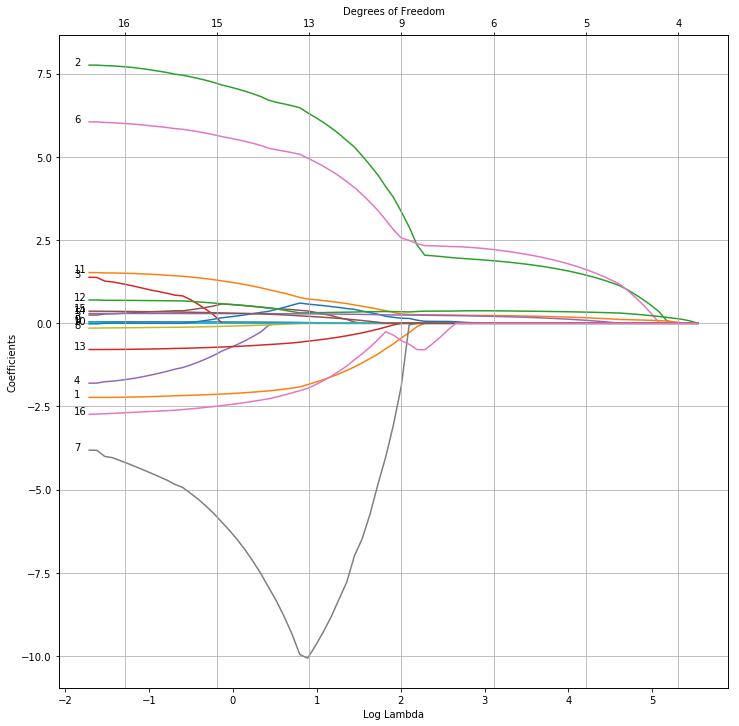

```
{'ax1': <matplotlib.axes._subplots.AxesSubplot at 0x18133edbe0>,
 'ax2': <matplotlib.axes._subplots.AxesSubplot at 0x111717668>,
 'fig': <matplotlib.figure.Figure at 0x1813069860>}
```

```python
from pylab import rcParams

fit = glmnet(x = x_, y = y_, alpha = 1)
rcParams['figure.figsize'] = 12, 12
glmnetPlot(fit, xvar = 'lambda', label = True)
```

## Problem 1.1.2

```python
import scipy
from glmnet import glmnet
from glmnet_python import glmnetCoef


Coef=glmnetCoef(fit, s = scipy.float64([185]), exact = False)
new_names=hitter.drop(['Salary', 'League', 'Division', 'NewLeague'], axis = 1).columns.values.tolist()
new_names.insert(0,"(Intercept)")
new_names.insert(1,"Intercept")
##new_names
names = pd.Series(new_names)

table=pd.DataFrame({"Predicators":names})
table["Coef"]=Coef
table
```

|  | Predicators | Coef |
| --- | --- | --- |
| 0 | (Intercept) | 457.975768 |
| 1 | Intercept | 0.000000 |
| 2 | AtBat | 0.000000 |
| 3 | Hits | 0.038133 |
| 4 | HmRun | 0.000000 |
| 5 | Runs | 0.000000 |
| 6 | RBI | 0.000000 |
| 7 | Walks | 0.000000 |
| 8 | Years | 0.000000 |
| 9 | CAtBat | 0.000000 |
| 10 | CHits | 0.000000 |
| 11 | CHmRun | 0.000000 |
| 12 | CRuns | 0.055180 |
| 13 | CRBI | 0.163145 |
| 14 | CWalks | 0.000000 |
| 15 | PutOuts | 0.000000 |
| 16 | Assists | 0.000000 |
| 17 | Errors | 0.000000 |

As we can observe above, after using the glmnetPredict, the output includes two rows of intercept 16 rows of predicators coefficients. We merged the them with the glmnetPredict output.

To sum this up, the final three predictors that remain in the model are “Hits” “CRuns”and “CRBI”, which means those three are the most important features to predict the predict the Hitters’ salary.

## Problem 1.1.3

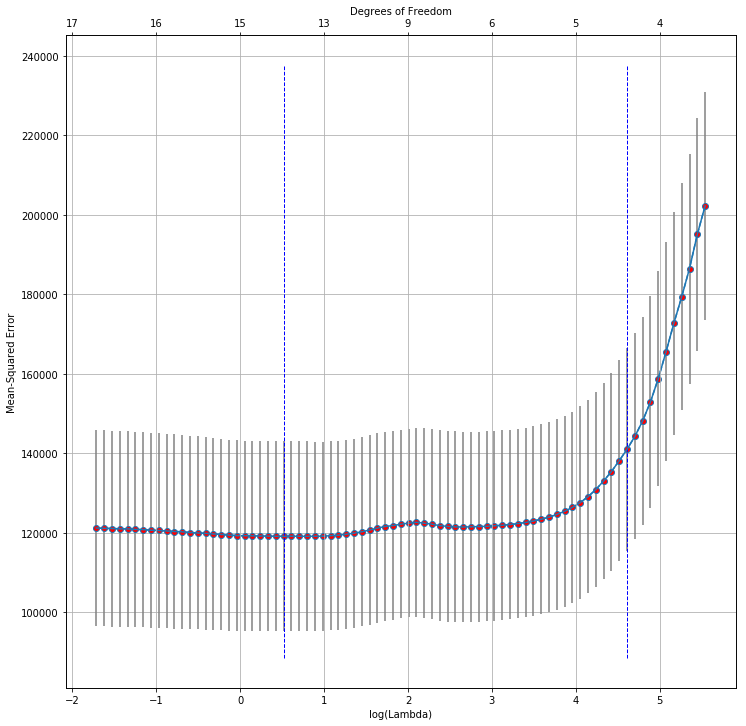

```python
import numpy
import warnings
warnings.filterwarnings('ignore')
cvfit_13 = cvglmnet(x = x_, y = y_ ,alpha=1 )
cvglmnetPlot(cvfit_13)
```

```python
for i in range(3,10):
    cvfit = cvglmnet(x = x_, y = y_ , ptype = 'mse', nfolds =i )
    print(cvfit['lambda_min'])
```

```
[ 20.7067179]
[ 1.05482879]
[ 2.02306696]
[ 2.43679131]
[ 2.02306696]
[ 2.93512376]
[ 2.93512376]
```

The the regularization penalty is 1.05482879 when the folds is 4. Therefore we plug this lambda back to the glmnet to predict:

## Problem 1.1.4

```python
Coef=glmnetCoef(fit, s = scipy.float64([1.05482879]), exact = False)
new_names=hitter.drop(['Salary', 'League', 'Division', 'NewLeague'], axis = 1).columns.values.tolist()
new_names.insert(0,"(Intercept)")
new_names.insert(1,"Intercept")
##new_names
names = pd.Series(new_names)

table=pd.DataFrame({"Predicators":names})
table["Coef"]=Coef
table
```

|  | Predicators | Coef |
| --- | --- | --- |
| 0 | (Intercept) | 105.849093 |
| 1 | Intercept | 0.038291 |
| 2 | AtBat | -2.100487 |
| 3 | Hits | 7.042706 |
| 4 | HmRun | 0.000000 |
| 5 | Runs | -0.635872 |
| 6 | RBI | 0.549348 |
| 7 | Walks | 5.518942 |
| 8 | Years | -6.508250 |
| 9 | CAtBat | -0.079919 |
| 10 | CHits | 0.000000 |
| 11 | CHmRun | 0.222068 |
| 12 | CRuns | 1.203207 |
| 13 | CRBI | 0.551477 |
| 14 | CWalks | -0.692886 |
| 15 | PutOuts | 0.292002 |
| 16 | Assists | 0.301030 |
| 17 | Errors | -2.414281 |

There are 14 predictors are left in the model

## Problem 1.2.1

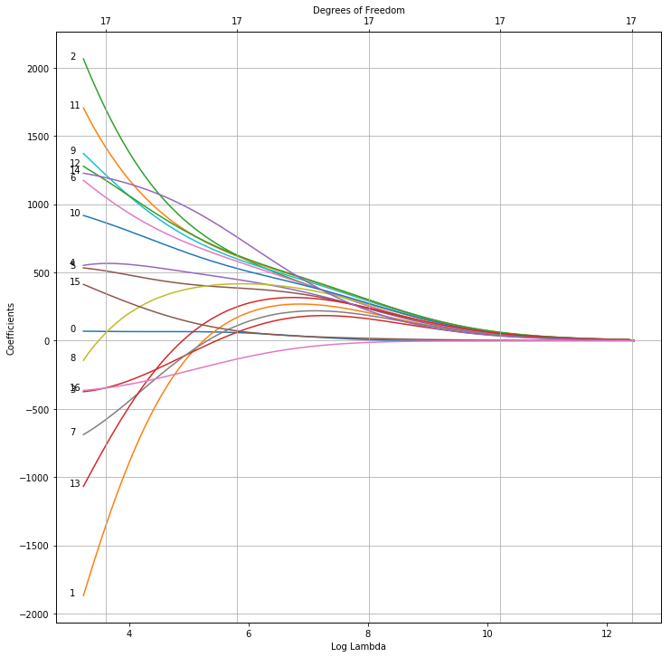

```
{'ax1': <matplotlib.axes._subplots.AxesSubplot at 0x111f646a0>,
 'ax2': <matplotlib.axes._subplots.AxesSubplot at 0x1813da4ac8>,
 'fig': <matplotlib.figure.Figure at 0x111f65550>}
```

```python
ridgefit=glmnet(x = x_, y = y_, alpha = 0)
glmnetPlot(ridgefit, xvar = 'lambda', label = True)
```

## Problem 1.2.2

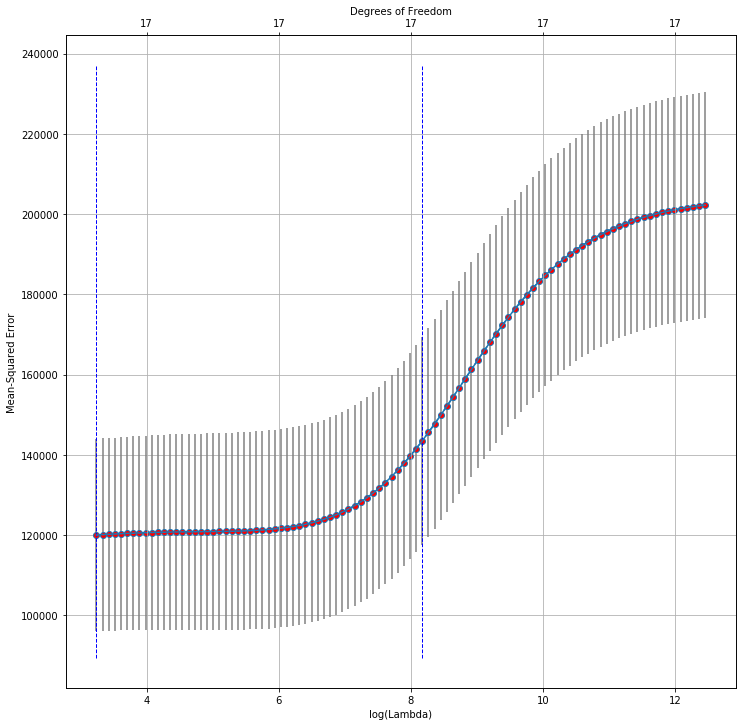

```python
cv_ridge=cvglmnet(x = x_, y = y_ ,alpha=0)
cvglmnetPlot(cv_ridge)
```

```python
print("The optimal value of ridge's regularization penalty: {0}".format(cv_ridge['lambda_min']))
```

```
The optimal value of ridge's regularization penalty: [ 25.52820965]
```

## 2 Short Answer

**Q**: 2.1 Explain in your own words the bias-variance tradeoff

The bias-variance tradeoff states that there is a tradeoff between a model's ability to minimize the bias and variance. In general, a flexible model tends to have a higher variance and lower bias, and vice versa.

**Q**: 2.2 What role does regularization play in this tradeoff?

Regulation is the technique to avoid overfitting, which the model is way too flexible with a high variance but low bias. Regulation technique makes a small modification to introduce the bias into the bias that can reduce the variace. In that case, the regulation technigue can generalize better model.

**Q**: 2.3 Make reference to your findings in number (1) to describe models of high/low bias and variance

Given the excersie from the problem set number(1), we find that the lambda impacts the penalty. In other words, regulaztion penalizes the coefficients by conrolling the lambda. In our case, we found that the smaller lambda yields the higher coefficients, therefore, it leads to a lower bias.